# R Notebook

```r
library(rethinking)
library(tidyverse)
```

# Problems

Assuming P is standardized:
$$T_i \sim\ Poisson(mu_i) \\
log(mu_i) = \alpha + \beta*log(P_{true,i}) \\
P_{obs,i} \sim normal(P_{true,i}, PSE_i)\\
P_{true,i} \sim normal(0, 1) \\
\alpha \sim normal(0,10) \\
\beta \sim normal(0,1)$$

## 15E2

*Rewrite the same model so that it allows imputation of missing values for log population. There aren’t any missing values in the variable, but you can still write down a model formula that would imply imputation, if any values were missing.*

$$T_i \sim\ Poisson(mu_i) \\
log(mu_i) = \alpha + \beta*log(P_{impute,i}) \\
P_{impute,i} \sim normal(\nu, \sigma_P)\\
\alpha \sim normal(0,10) \\
\beta \sim normal(0,1) \\
\nu \sim normal(0,1) \\
\sigma_P \sim exp(1)$$

## 15M3.

### original

```r
data(WaffleDivorce)
d <- WaffleDivorce
## R code 15.3
dlist <- list(
    D_obs = standardize( d$Divorce ),
    D_sd = d$Divorce.SE / sd( d$Divorce ),
    M = standardize( d$Marriage ),
    A = standardize( d$MedianAgeMarriage ),
    N = nrow(d)
)

m15.1 <- ulam(
    alist(
        D_obs ~ dnorm( D_true , D_sd ),
        vector[N]:D_true ~ dnorm( mu , sigma ),
        mu <- a + bA*A + bM*M,
        a ~ dnorm(0,0.2),
        bA ~ dnorm(0,0.5),
        bM ~ dnorm(0,0.5),
        sigma ~ dexp(1)
    ) , data=dlist , chains=4 , cores=4 )
```

```
starting worker pid=57955 on localhost:11139 at 15:32:45.492
starting worker pid=57969 on localhost:11139 at 15:32:45.814
starting worker pid=57983 on localhost:11139 at 15:32:46.139
starting worker pid=57997 on localhost:11139 at 15:32:46.417
```

### Double standard error

```r
## R code 15.3
dlist2 <- list(
    D_obs = standardize( d$Divorce ),
    D_sd = 2*d$Divorce.SE / sd( d$Divorce ),
    M = standardize( d$Marriage ),
    A = standardize( d$MedianAgeMarriage ),
    N = nrow(d)
)

m15.1.2 <- ulam(
    alist(
        D_obs ~ dnorm( D_true , D_sd ),
        vector[N]:D_true ~ dnorm( mu , sigma ),
        mu <- a + bA*A + bM*M,
        a ~ dnorm(0,0.2),
        bA ~ dnorm(0,0.5),
        bM ~ dnorm(0,0.5),
        sigma ~ dexp(1)
    ) , data=dlist2 , chains=4 , cores=4 )
```

```
recompiling to avoid crashing R session
```

```
starting worker pid=58131 on localhost:11139 at 15:33:43.355
starting worker pid=58145 on localhost:11139 at 15:33:43.873
starting worker pid=58159 on localhost:11139 at 15:33:44.150
starting worker pid=58173 on localhost:11139 at 15:33:44.456
```

[output not shown]

```r
precis(m15.1)
```

```
50 vector or matrix parameters hidden. Use depth=2 to show them.
```

|  | mean | sd | 5.5% | 94.5% | n_eff | Rhat4 |
| --- | --- | --- | --- | --- | --- | --- |
| a | -0.05 | 0.10 | -0.20 | 0.10 | 1427 | 1.00 |
| bA | -0.61 | 0.16 | -0.86 | -0.35 | 764 | 1.01 |
| bM | 0.05 | 0.17 | -0.22 | 0.33 | 701 | 1.01 |
| sigma | 0.59 | 0.10 | 0.43 | 0.75 | 734 | 1.00 |

```r
precis(m15.1.2)
```

```
50 vector or matrix parameters hidden. Use depth=2 to show them.
```

|  | mean | sd | 5.5% | 94.5% | n_eff | Rhat4 |
| --- | --- | --- | --- | --- | --- | --- |
| a | -0.13 | 0.10 | -0.28 | 0.03 | 124 | 1.02 |
| bA | -0.66 | 0.17 | -0.93 | -0.38 | 183 | 1.02 |
| bM | 0.18 | 0.20 | -0.13 | 0.49 | 167 | 1.03 |
| sigma | 0.16 | 0.09 | 0.04 | 0.33 | 35 | 1.10 |

Doubling the measurement standard error noticebly reduces sigma, because it allows the observations to get “shrunk” more.

## 15H1

*The data in data(elephants) are counts of matings observed for bull elephants of differing ages. There is a strong positive relationship between age and matings. However, age is not always assessed accurately. First, fit a Poisson model predicting MATINGS with AGE as a predictor. Second, assume that the observed AGE values are uncertain and have a standard error of ±5 years. Re-estimate the relationship between MATINGS and AGE, incorporating this measurement error. Compare the inferences of the two models.*

```r
data("elephants")
str(elephants)
```

```
'data.frame':   41 obs. of  2 variables:
 $ AGE    : int  27 28 28 28 28 29 29 29 29 29 ...
 $ MATINGS: int  0 1 1 1 3 0 0 0 2 2 ...
```

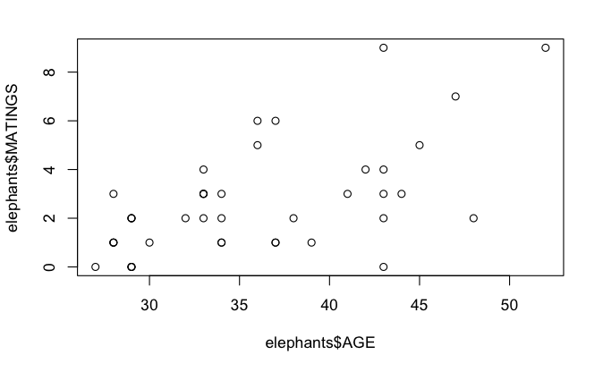

```r
plot(elephants$AGE, elephants$MATINGS)
```

```r
d <- list(M = elephants$MATINGS, A = standardize(elephants$AGE))
```

check the priors

```r
age <- seq(min(d$A), max(d$A), by = .1)
priorpred1 <- tibble(
  id = 1:100,
  a = rnorm(100, 0, 1),
  b = rnorm(100, 0, 1))

priorpred1 <- priorpred1 %>%
  mutate(pred=map2(a,b, ~ exp(.x + .y*age)),
         pred=map(pred, ~ tibble(M=.,A=age))) %>% # add age column
  unnest(pred)
priorpred1
```

| id | a | b | M | A |
| --- | --- | --- | --- | --- |
| 1 | 0.37659177 | -0.2218393600 | 1.96432557 | -1.34582606 |
| 1 | 0.37659177 | -0.2218393600 | 1.92122889 | -1.24582606 |
| 1 | 0.37659177 | -0.2218393600 | 1.87907774 | -1.14582606 |
| 1 | 0.37659177 | -0.2218393600 | 1.83785137 | -1.04582606 |
| 1 | 0.37659177 | -0.2218393600 | 1.79752949 | -0.94582606 |
| 1 | 0.37659177 | -0.2218393600 | 1.75809227 | -0.84582606 |
| 1 | 0.37659177 | -0.2218393600 | 1.71952028 | -0.74582606 |
| 1 | 0.37659177 | -0.2218393600 | 1.68179456 | -0.64582606 |
| 1 | 0.37659177 | -0.2218393600 | 1.64489652 | -0.54582606 |
| 1 | 0.37659177 | -0.2218393600 | 1.60880801 | -0.44582606 |

[output cut: 990 more lines]

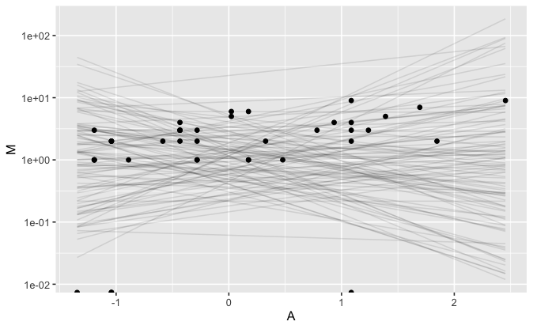

```r
priorpred1 %>%
  ggplot(aes(x=A, y=M)) +
  geom_line(aes(group=id), alpha=.1)+
  geom_point(data=as.data.frame(d)) +
  scale_y_log10()
```

```r
mh1.1 <- ulam(
  alist(M ~ dpois(lambda),
        log(lambda) <- a + bA*A,
        a ~ dnorm(0,1),
        bA ~ dnorm(0,1)),
  data = d,
  chains = 4,
  cores = 4)
```

```
starting worker pid=58313 on localhost:11139 at 15:34:24.904
starting worker pid=58327 on localhost:11139 at 15:34:25.228
starting worker pid=58341 on localhost:11139 at 15:34:25.577
starting worker pid=58355 on localhost:11139 at 15:34:25.987
```

```r
precis(mh1.1)
```

|  | mean | sd | 5.5% | 94.5% | n_eff | Rhat4 |
| --- | --- | --- | --- | --- | --- | --- |
| a | 0.86 | 0.11 | 0.68 | 1.03 | 941 | 1 |
| bA | 0.45 | 0.09 | 0.31 | 0.60 | 1027 | 1 |

```r
pred1 <- link(mh1.1, data=list(A=age))
dim(pred1)
```

```
[1] 2000   39
```

```r
pred.plot1 <- tibble(
  A=age,
  M=apply(pred1,2,mean),
  lower=apply(pred1,2,HPDI)[1,],
  upper=apply(pred1,2,HPDI)[2,],
)
```

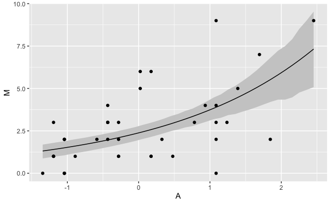

```r
pred.plot1 %>%
  ggplot(aes(x=A,y=M)) +
  geom_ribbon(aes(ymin=lower,ymax=upper),fill="gray80") +
    geom_line() +
  geom_point(data=as.data.frame(d))
```

### now with standard error

```r
sem_std <- 5/sd(elephants$AGE)
d$N <- length(d$A)
d$sem_std <- sem_std
mh1.2 <- ulam(
  alist(M ~ dpois(lambda),
        log(lambda) <- a + bA*Aest[i],
        A ~ dnorm(Aest, sem_std),
        vector[N]:Aest ~ dnorm(0,1),
        a ~ dnorm(0,1),
        bA ~ dnorm(0,1)),
  data = d,
  chains = 4,
  cores = 4)
```

```
starting worker pid=58492 on localhost:11139 at 15:35:06.783
starting worker pid=58506 on localhost:11139 at 15:35:07.079
starting worker pid=58520 on localhost:11139 at 15:35:07.365
starting worker pid=58534 on localhost:11139 at 15:35:07.633
```

```r
precis(mh1.1)
```

|  | mean | sd | 5.5% | 94.5% | n_eff | Rhat4 |
| --- | --- | --- | --- | --- | --- | --- |
| a | 0.86 | 0.11 | 0.68 | 1.03 | 941 | 1 |
| bA | 0.45 | 0.09 | 0.31 | 0.60 | 1027 | 1 |

```r
precis(mh1.2)
```

```
41 vector or matrix parameters hidden. Use depth=2 to show them.
```

|  | mean | sd | 5.5% | 94.5% | n_eff | Rhat4 |
| --- | --- | --- | --- | --- | --- | --- |
| a | 0.81 | 0.13 | 0.60 | 1.01 | 2459 | 1 |
| bA | 0.66 | 0.15 | 0.44 | 0.92 | 1286 | 1 |

bA somewhat larger; and larger error

```r
pred2 <- link(mh1.2, data=list(A=age))
dim(pred2)
```

```
[1] 2000   39
```

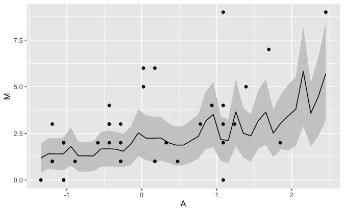

```r
pred.plot2 <- tibble(
  A=age,
  M=apply(pred2,2,mean),
  lower=apply(pred2,2,HPDI)[1,],
  upper=apply(pred2,2,HPDI)[2,],
)

pred.plot2 %>%
  ggplot(aes(x=A,y=M)) +
  geom_ribbon(aes(ymin=lower,ymax=upper),fill="gray80") +
    geom_line() +
  geom_point(data=as.data.frame(d))
```

Not working well; because of variation due to SE? Maybe need to pull out coefficents and make predictions from that?

```r
post <- extract.samples(mh1.2)
str(post)
```

```
List of 3
 $ Aest: num [1:2000, 1:41] -0.858 -0.484 -1.525 -0.31 -1.004 ...
 $ a   : num [1:2000(1d)] 0.811 0.807 0.944 0.661 0.821 ...
 $ bA  : num [1:2000(1d)] 0.663 0.438 0.537 0.601 0.536 ...
 - attr(*, "source")= chr "ulam posterior: 2000 samples from mh1.2"
```

## 15H2

```r
dofit <- function(SE, dtmp=d )
{
  sem_std <- SE/sd(elephants$AGE)
dtmp$N <- length(d$A)
dtmp$sem_std <- sem_std
m.tmp <- ulam(
  alist(M ~ dpois(lambda),
        log(lambda) <- a + bA*Aest[i],
        A ~ dnorm(Aest, sem_std),
        vector[N]:Aest ~ dnorm(0,1),
        a ~ dnorm(0,1),
        bA ~ dnorm(0,1)),
  data = dtmp,
  chains = 4,
  cores = 4)
p.tmp <- precis(m.tmp) %>% data.frame() %>% rownames_to_column("coef")
return(p.tmp)
}

H2.table <- tibble(SE=c(5, 10, 15, 20, 25, 50, 100))
```

```r
H2.table <- H2.table %>%
  mutate(results=map(SE, dofit))
```

```
recompiling to avoid crashing R session
```

```
starting worker pid=58666 on localhost:11139 at 15:35:49.074
starting worker pid=58680 on localhost:11139 at 15:35:49.375
starting worker pid=58694 on localhost:11139 at 15:35:49.706
starting worker pid=58708 on localhost:11139 at 15:35:50.128
```

```
41 vector or matrix parameters hidden. Use depth=2 to show them.
recompiling to avoid crashing R session
```

```
starting worker pid=58887 on localhost:11139 at 15:36:28.958
starting worker pid=58901 on localhost:11139 at 15:36:29.312
starting worker pid=58915 on localhost:11139 at 15:36:29.675
starting worker pid=58929 on localhost:11139 at 15:36:29.998



Chain Chain 3: Iteration: 400 / 1000 [ 40%]  (Warmup)
2: Iteration: 900 / 1000 [ 90%]  (Sampling)
```

```
41 vector or matrix parameters hidden. Use depth=2 to show them.
recompiling to avoid crashing R session
```

```
starting worker pid=59062 on localhost:11139 at 15:37:08.298
starting worker pid=59076 on localhost:11139 at 15:37:08.635
starting worker pid=59090 on localhost:11139 at 15:37:08.918
starting worker pid=59104 on localhost:11139 at 15:37:09.212




Chain Chain 4: Iteration: 200 / 1000 [ 20%]  (Warmup)
3: Iteration: 501 / 1000 [ 50%]  (Sampling)
```

```
41 vector or matrix parameters hidden. Use depth=2 to show them.
recompiling to avoid crashing R session
```

```
starting worker pid=59238 on localhost:11139 at 15:37:43.431
starting worker pid=59252 on localhost:11139 at 15:37:43.732
starting worker pid=59266 on localhost:11139 at 15:37:44.017
starting worker pid=59280 on localhost:11139 at 15:37:44.299




Chain 4Chain 3: Iteration: 900 / 1000 [ 90%]  (Sampling)
: Iteration: 400 / 1000 [ 40%]  (Warmup)
```

```
41 vector or matrix parameters hidden. Use depth=2 to show them.
recompiling to avoid crashing R session
```

```
starting worker pid=59425 on localhost:11139 at 15:38:26.634
starting worker pid=59439 on localhost:11139 at 15:38:26.980
starting worker pid=59453 on localhost:11139 at 15:38:27.244
starting worker pid=59467 on localhost:11139 at 15:38:27.521




Chain Chain 3: Iteration: 800 / 1000 [ 80%]  (Sampling)
4: Iteration: 300 / 1000 [ 30%]  (Warmup)
```

[output not shown]

```
starting worker pid=59596 on localhost:11139 at 15:38:58.940
starting worker pid=59610 on localhost:11139 at 15:38:59.225
starting worker pid=59624 on localhost:11139 at 15:38:59.512
starting worker pid=59638 on localhost:11139 at 15:38:59.780
```

[output not shown]

```
starting worker pid=59767 on localhost:11139 at 15:39:29.257
starting worker pid=59781 on localhost:11139 at 15:39:29.531
starting worker pid=59795 on localhost:11139 at 15:39:29.827
starting worker pid=59809 on localhost:11139 at 15:39:30.097
```

[output not shown]

```r
H2.table %>%  unnest(results) %>% arrange(desc(coef), SE)
```

| SE | coef | mean | sd | X5.5. | X94.5. | n_eff | Rhat4 |
| --- | --- | --- | --- | --- | --- | --- | --- |
| 5 | bA | 0.652072187 | 0.1474370 | 0.4298424 | 0.8999176 | 1362.084804 | 0.9986075 |
| 10 | bA | 0.646796514 | 0.1571100 | 0.4035010 | 0.9106592 | 1202.133025 | 1.0015258 |
| 15 | bA | 0.615796159 | 0.1520295 | 0.3910409 | 0.8592432 | 1009.561965 | 1.0003548 |
| 20 | bA | 0.600312183 | 0.1615729 | 0.3595300 | 0.8683324 | 809.258083 | 1.0003712 |
| 25 | bA | 0.297081679 | 0.5297849 | -0.6888381 | 0.8099380 | 2.158414 | 3.5803513 |
| 50 | bA | -0.239448245 | 0.5437150 | -0.7947664 | 0.6911524 | 2.706257 | 2.2455095 |
| 100 | bA | -0.001907457 | 0.5908486 | -0.7652494 | 0.7536948 | 2.129116 | 3.9387733 |
| 5 | a | 0.809049064 | 0.1268212 | 0.6121395 | 1.0117467 | 2029.348286 | 0.9999242 |
| 10 | a | 0.797474811 | 0.1451229 | 0.5467760 | 1.0101461 | 1586.612938 | 1.0027946 |
| 15 | a | 0.803137571 | 0.1409461 | 0.5730678 | 1.0145326 | 1923.742795 | 0.9994890 |

[output cut: 4 more lines]

## PDF1

```r
library(rethinking)
data(Primates301)
d <- Primates301
cc <- complete.cases( d$brain , d$body )
B <- d$brain[cc]
M <- d$body[cc]
B <- B / max(B)
M <- M / max(M)

# make up some SE
 Bse <- B*0.1
 Mse <- M*0.1
```

model with out SE info:

```r
dat_list <- list( B=B, M=M)

m1.1 <- ulam( alist(
  B ~ dlnorm( mu , sigma ),
  mu <- a + b*log(M),
  a ~ normal(0,1),
  b ~ normal(0,1),
  sigma ~ exponential(1)),
  data=dat_list, chains = 4, cores = 4 )
```

```
starting worker pid=59936 on localhost:11139 at 15:39:59.266
starting worker pid=59950 on localhost:11139 at 15:39:59.539
starting worker pid=59964 on localhost:11139 at 15:39:59.814
starting worker pid=59978 on localhost:11139 at 15:40:00.091
```

```r
precis(m1.1)
```

|  | mean | sd | 5.5% | 94.5% | n_eff | Rhat4 |
| --- | --- | --- | --- | --- | --- | --- |
| a | 0.43 | 0.06 | 0.33 | 0.52 | 759 | 1 |
| b | 0.78 | 0.01 | 0.76 | 0.81 | 751 | 1 |
| sigma | 0.29 | 0.02 | 0.27 | 0.32 | 670 | 1 |

now add SE into the model

```r
dat_list <- list( Bobs=B, Mobs=M, Bse=Bse, Mse=Mse, N=length(B))

m1.2 <- ulam( alist(
  vector[N]:Btrue ~ dlnorm( mu , sigma ),
  mu <- a + b*log(Mtrue[i]),
  Mobs ~ dnorm(Mtrue, Mse),
  Bobs ~ dnorm(Btrue, Bse),
  vector[N]:Mtrue ~ dnorm(0.5,0.25),
  a ~ normal(0,1),
  b ~ normal(0,1),
  sigma ~ exponential(1)),
  data=dat_list,
  start=list( Mtrue=dat_list$Mobs , Btrue=dat_list$Bobs ),
  chains = 4,
  cores = 4,
  control = list(max_treedepth=25))
```

```
starting worker pid=60105 on localhost:11139 at 15:40:31.507
starting worker pid=60119 on localhost:11139 at 15:40:31.774
starting worker pid=60133 on localhost:11139 at 15:40:32.036
starting worker pid=60147 on localhost:11139 at 15:40:32.294
```

```r
precis(m1.1)
```

|  | mean | sd | 5.5% | 94.5% | n_eff | Rhat4 |
| --- | --- | --- | --- | --- | --- | --- |
| a | 0.43 | 0.06 | 0.33 | 0.52 | 759 | 1 |
| b | 0.78 | 0.01 | 0.76 | 0.81 | 751 | 1 |
| sigma | 0.29 | 0.02 | 0.27 | 0.32 | 670 | 1 |

```r
precis(m1.2)
```

```
364 vector or matrix parameters hidden. Use depth=2 to show them.
```

|  | mean | sd | 5.5% | 94.5% | n_eff | Rhat4 |
| --- | --- | --- | --- | --- | --- | --- |
| a | 0.41 | 0.06 | 0.32 | 0.51 | 868 | 1 |
| b | 0.78 | 0.01 | 0.76 | 0.81 | 883 | 1 |
| sigma | 0.26 | 0.02 | 0.24 | 0.29 | 1488 | 1 |

The parameter estimates for a and b are almost exactly the same. sigma for the model with SE is a bit lower, presumably because the estimated true values are shrunk.

## PDF2

missing data. focus on when missing values in the brain data set

```r
data(Primates301)
d <- Primates301
colSums( is.na(d) )
```

```
               name               genus             species
                  0                   0                   0
         subspecies              spp_id            genus_id
                267                   0                   0
    social_learning     research_effort               brain
                 98                 115                 117
               body          group_size           gestation
                 63                 114                 161
            weaning           longevity        sex_maturity
                185                 181                 194
maternal_investment
                197
```

```r
cc <- complete.cases( d$body )
M <- d$body[cc]
M <- M / max(M)
B <- d$brain[cc]
B <- B / max( B , na.rm=TRUE )
```

*First, consider whether there is a pattern to the missing values. Does it look like missing values are associated with particular values of body mass? Draw a DAG that represents how missingness works in this case. Which type (MCAR, MAR, MNAR) is this?*

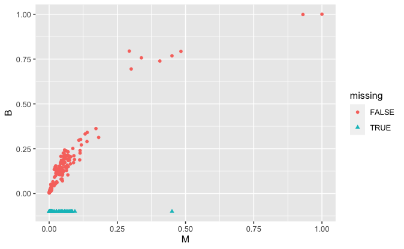

```r
tibble(B=B, M=M, missing=is.na(B)) %>%
  mutate(B=ifelse(is.na(B),-.1,B)) %>%
  ggplot(aes(x=M, y=B, shape=missing, color=missing)) +
  geom_point()
```

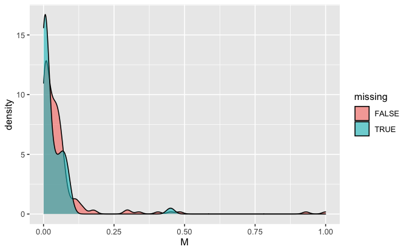

```r
tibble(B=B, M=M, missing=is.na(B)) %>%
  ggplot(aes(x=M, fill=missing)) +
  geom_density(alpha=.6)
```

more missing brain data at low M

```r
library(ggdag)
```

[figure not shown]

```r
set.seed(3)
dagify(B ~ M,
       Bobs ~ B + Rb,
       Rb ~ M) %>%
  ggdag()
```

```r
NA
NA
```

This is MAR

### Compare complete cases and imputed

### complete cases only

```r
dat_df <- data.frame( B=B, M=M)
dat_df_cc <- na.omit(dat_df)

m2.1 <- ulam( alist(
  B ~ dlnorm( mu , sigma ),
  mu <- a + b*log(M),
  a ~ normal(0,1),
  b ~ normal(0,1),
  sigma ~ exponential(1)),
  data=dat_df_cc, chains = 4, cores = 4 )
```

```
starting worker pid=60259 on localhost:11139 at 15:45:20.811
starting worker pid=60273 on localhost:11139 at 15:45:21.242
starting worker pid=60287 on localhost:11139 at 15:45:21.589
starting worker pid=60301 on localhost:11139 at 15:45:21.957
```

```r
precis(m2.1)
```

|  | mean | sd | 5.5% | 94.5% | n_eff | Rhat4 |
| --- | --- | --- | --- | --- | --- | --- |
| a | 0.43 | 0.06 | 0.34 | 0.53 | 828 | 1 |
| b | 0.78 | 0.01 | 0.76 | 0.81 | 861 | 1 |
| sigma | 0.29 | 0.02 | 0.27 | 0.32 | 933 | 1 |

### with imputation

```r
dat_list <- list( B=B, M=M, N=length(M))

m2.2 <- ulam( alist(
  B_merge ~ dlnorm( mu , sigma ),
  mu <- a + b*log(M),
  a ~ normal(0,1),
  b ~ normal(0,1),
  vector[N]:B_merge <- merge_missing(B, B_impute),
  sigma ~ exponential(1)),
  data=dat_list, chains = 4, cores = 4,
 start=list( B_impute=rep(0.5,56) ))
```

```
starting worker pid=60426 on localhost:11139 at 15:46:07.983
starting worker pid=60440 on localhost:11139 at 15:46:08.337
starting worker pid=60454 on localhost:11139 at 15:46:08.718
starting worker pid=60468 on localhost:11139 at 15:46:09.271
```

```r
stancode(m2.2)
```

```
functions{

    vector merge_missing( int[] miss_indexes , vector x_obs , vector x_miss ) {
        int N = dims(x_obs)[1];
        int N_miss = dims(x_miss)[1];
        vector[N] merged;
        merged = x_obs;
        for ( i in 1:N_miss )
            merged[ miss_indexes[i] ] = x_miss[i];
        return merged;
    }
}
data{
    int N;
    vector[238] M;
    vector[238] B;
    int B_missidx[56];
}
parameters{
    real a;
    real b;
    real<lower=0> sigma;
    vector[56] B_impute;
}
model{
    vector[238] mu;
    vector[N] B_merge;
    sigma ~ exponential( 1 );
    B_merge = merge_missing(B_missidx, to_vector(B), B_impute);
    b ~ normal( 0 , 1 );
    a ~ normal( 0 , 1 );
    for ( i in 1:238 ) {
        mu[i] = a + b * log(M[i]);
    }
    B_merge ~ lognormal( mu , sigma );
}
```

```r
precis(m2.2, depth = 2)
```

|  | mean | sd | 5.5% | 94.5% | n_eff | Rhat4 |
| --- | --- | --- | --- | --- | --- | --- |
| a | 0.43 | 0.06 | 0.34 | 0.52 | 939 | 1.00 |
| b | 0.78 | 0.01 | 0.76 | 0.81 | 941 | 1.00 |
| sigma | 0.29 | 0.02 | 0.27 | 0.32 | 1435 | 1.00 |
| B_impute[1] | 0.00 | 0.00 | 0.00 | 0.01 | 1270 | 1.00 |
| B_impute[2] | 0.03 | 0.01 | 0.02 | 0.05 | 1801 | 1.00 |
| B_impute[3] | 0.03 | 0.01 | 0.02 | 0.05 | 1559 | 1.01 |
| B_impute[4] | 0.03 | 0.01 | 0.02 | 0.04 | 1628 | 1.00 |
| B_impute[5] | 0.22 | 0.07 | 0.13 | 0.34 | 1533 | 1.00 |
| B_impute[6] | 0.03 | 0.01 | 0.02 | 0.05 | 1785 | 1.00 |
| B_impute[7] | 0.04 | 0.01 | 0.02 | 0.06 | 1483 | 1.00 |

[output cut: 49 more lines]

```r
precis(m2.1)
```

|  | mean | sd | 5.5% | 94.5% | n_eff | Rhat4 |
| --- | --- | --- | --- | --- | --- | --- |
| a | 0.43 | 0.06 | 0.34 | 0.53 | 828 | 1 |
| b | 0.78 | 0.01 | 0.76 | 0.81 | 861 | 1 |
| sigma | 0.29 | 0.02 | 0.27 | 0.32 | 933 | 1 |

Same!

## 15H4 (optional)

# Book

```r
## R code 15.1
# simulate a pancake and return randomly ordered sides
sim_pancake <- function() {
    pancake <- sample(1:3,1)
    sides <- matrix(c(1,1,1,0,0,0),2,3)[,pancake]
    sample(sides)
}

# sim 10,000 pancakes
pancakes <- replicate( 1e4 , sim_pancake() )
up <- pancakes[1,]
down <- pancakes[2,]

# compute proportion 1/1 (BB) out of all 1/1 and 1/0
num_11_10 <- sum( up==1 )
num_11 <- sum( up==1 & down==1 )
num_11/num_11_10
```

```r
## R code 15.2
library(rethinking)
data(WaffleDivorce)
d <- WaffleDivorce

# points
plot( d$Divorce ~ d$MedianAgeMarriage , ylim=c(4,15) ,
    xlab="Median age marriage" , ylab="Divorce rate" )

# standard errors
for ( i in 1:nrow(d) ) {
    ci <- d$Divorce[i] + c(-1,1)*d$Divorce.SE[i]
    x <- d$MedianAgeMarriage[i]
    lines( c(x,x) , ci )
}
```

```r
## R code 15.3
dlist <- list(
    D_obs = standardize( d$Divorce ),
    D_sd = d$Divorce.SE / sd( d$Divorce ),
    M = standardize( d$Marriage ),
    A = standardize( d$MedianAgeMarriage ),
    N = nrow(d)
)

m15.1 <- ulam(
    alist(
        D_obs ~ dnorm( D_true , D_sd ),
        vector[N]:D_true ~ dnorm( mu , sigma ),
        mu <- a + bA*A + bM*M,
        a ~ dnorm(0,0.2),
        bA ~ dnorm(0,0.5),
        bM ~ dnorm(0,0.5),
        sigma ~ dexp(1)
    ) , data=dlist , chains=4 , cores=4 )
```

```r
## R code 15.4
precis( m15.1 , depth=2 )
```

```r
## R code 15.5
dlist <- list(
    D_obs = standardize( d$Divorce ),
    D_sd = d$Divorce.SE / sd( d$Divorce ),
    M_obs = standardize( d$Marriage ),
    M_sd = d$Marriage.SE / sd( d$Marriage ),
    A = standardize( d$MedianAgeMarriage ),
    N = nrow(d)
)

m15.2 <- ulam(
    alist(
        D_obs ~ dnorm( D_est , D_sd ),
        vector[N]:D_est ~ dnorm( mu , sigma ),
        mu <- a + bA*A + bM*M_est[i],
        M_obs ~ dnorm( M_est , M_sd ),
        vector[N]:M_est ~ dnorm( 0 , 1 ),
        a ~ dnorm(0,0.2),
        bA ~ dnorm(0,0.5),
        bM ~ dnorm(0,0.5),
        sigma ~ dexp( 1 )
    ) , data=dlist , chains=4 , cores=4 )
```

```r
## R code 15.6
post <- extract.samples( m15.2 )
D_est <- apply( post$D_est , 2 , mean )
M_est <- apply( post$M_est , 2 , mean )
plot( dlist$M_obs , dlist$D_obs , pch=16 , col=rangi2 ,
    xlab="marriage rate (std)" , ylab="divorce rate (std)" )
points( M_est , D_est )
for ( i in 1:nrow(d) )
    lines( c( dlist$M_obs[i] , M_est[i] ) , c( dlist$D_obs[i] , D_est[i] ) )
```

```r
## R code 15.7
N <- 500
A <- rnorm(N)
M <- rnorm(N,-A)
D <- rnorm(N,A)
A_obs <- rnorm(N,A)
```

```r
## R code 15.8
N <- 100
S <- rnorm( N )
H <- rbinom( N , size=10 , inv_logit(S) )

## R code 15.9
D <- rbern( N ) # dogs completely random
Hm <- H
Hm[D==1] <- NA

## R code 15.10
D <- ifelse( S > 0 , 1 , 0 )
Hm <- H
Hm[D==1] <- NA

## R code 15.11
set.seed(501)
N <- 1000
X <- rnorm(N)
S <- rnorm(N)
H <- rbinom( N , size=10 , inv_logit( 2 + S - 2*X ) )
D <- ifelse( X > 1 , 1 , 0 )
Hm <- H
Hm[D==1] <- NA

## R code 15.12
dat_list <- list(
    H = H,
    S = S )

m15.3 <- ulam(
    alist(
        H ~ binomial( 10 , p ),
        logit(p) <- a + bS*S,
        a ~ normal( 0 , 1 ),
        bS ~ normal( 0 , 0.5 )
    ), data=dat_list , chains=4 )
precis( m15.3 )

## R code 15.13
dat_list0 <- list(
    H = H[D==0],
    S = S[D==0] )

m15.4 <- ulam(
    alist(
        H ~ binomial( 10 , p ),
        logit(p) <- a + bS*S,
        a ~ normal( 0 , 1 ),
        bS ~ normal( 0 , 0.5 )
    ), data=dat_list0 , chains=4 )
precis( m15.4 )

## R code 15.14
D <- ifelse( abs(X) < 1 , 1 , 0 )

## R code 15.15
N <- 100
S <- rnorm(N)
H <- rbinom( N , size=10 , inv_logit(S) )
D <- ifelse( H < 5 , 1 , 0 )
Hm <- H
Hm[D==1] <- NA

## R code 15.16
library(rethinking)
data(milk)
d <- milk
d$neocortex.prop <- d$neocortex.perc / 100
d$logmass <- log(d$mass)

## R code 15.17
dat_list <- list(
    K = standardize( d$kcal.per.g ),
    B = standardize( d$neocortex.prop ),
    M = standardize( d$logmass )
)

m15.3 <- ulam(
    alist(
        K ~ dnorm( mu , sigma ),
        mu <- a + bB*B + bM*M,
        B ~ dnorm( nu , sigma_B ),
        c(a,nu) ~ dnorm( 0 , 0.5 ),
        c(bB,bM) ~ dnorm( 0, 0.5 ),
        sigma_B ~ dexp( 1 ),
        sigma ~ dexp( 1 )
    ) , data=dat_list , chains=4 , cores=4 )

## R code 15.18
precis( m15.3 , depth=2 )

## R code 15.19
obs_idx <- which( !is.na(d$neocortex.prop) )
dat_list_obs <- list(
    K = dat_list$K[obs_idx],
    B = dat_list$B[obs_idx],
    M = dat_list$M[obs_idx]
)
m15.4 <- ulam(
    alist(
        K ~ dnorm( mu , sigma ),
        mu <- a + bB*B + bM*M,
        B ~ dnorm( nu , sigma_B ),
        c(a,nu) ~ dnorm( 0 , 0.5 ),
        c(bB,bM) ~ dnorm( 0, 0.5 ),
        sigma_B ~ dexp( 1 ),
        sigma ~ dexp( 1 )
    ) , data=dat_list_obs , chains=4 , cores=4 )
precis( m15.4 )

## R code 15.20
plot( coeftab(m15.3,m15.4) , pars=c("bB","bM") )

## R code 15.21
post <- extract.samples( m15.3 )
B_impute_mu <- apply( post$B_impute , 2 , mean )
B_impute_ci <- apply( post$B_impute , 2 , PI )

# B vs K
plot( dat_list$B , dat_list$K , pch=16 , col=rangi2 ,
    xlab="neocortex percent (std)" , ylab="kcal milk (std)" )
miss_idx <- which( is.na(dat_list$B) )
Ki <- dat_list$K[miss_idx]
points( B_impute_mu , Ki )
for ( i in 1:12 ) lines( B_impute_ci[,i] , rep(Ki[i],2) )

# M vs B
plot( dat_list$M , dat_list$B , pch=16 , col=rangi2 ,
    ylab="neocortex percent (std)" , xlab="log body mass (std)" )
Mi <- dat_list$M[miss_idx]
points( Mi , B_impute_mu )
for ( i in 1:12 ) lines( rep(Mi[i],2) , B_impute_ci[,i] )

## R code 15.22
m15.5 <- ulam(
    alist(
       # K as function of B and M
        K ~ dnorm( mu , sigma ),
        mu <- a + bB*B_merge + bM*M,

       # M and B correlation
        MB ~ multi_normal( c(muM,muB) , Rho_BM , Sigma_BM ),
        matrix[29,2]:MB <<- append_col( M , B_merge ),

       # define B_merge as mix of observed and imputed values
        vector[29]:B_merge <- merge_missing( B , B_impute ),

       # priors
        c(a,muB,muM) ~ dnorm( 0 , 0.5 ),
        c(bB,bM) ~ dnorm( 0, 0.5 ),
        sigma ~ dexp( 1 ),
        Rho_BM ~ lkj_corr(2),
        Sigma_BM ~ exponential(1)
    ) , data=dat_list , chains=4 , cores=4 )
precis( m15.5 , depth=3 , pars=c("bM","bB","Rho_BM" ) )

## R code 15.23
B_missidx <- which( is.na( dat_list$B ) )

## R code 15.24
data(Moralizing_gods)
str(Moralizing_gods)

## R code 15.25
table( Moralizing_gods$moralizing_gods , useNA="always" )

## R code 15.26
symbol <- ifelse( Moralizing_gods$moralizing_gods==1 , 16 , 1 )
symbol <- ifelse( is.na(Moralizing_gods$moralizing_gods) , 4 , symbol )
color <- ifelse( is.na(Moralizing_gods$moralizing_gods) , "black" , rangi2 )
plot( Moralizing_gods$year , Moralizing_gods$population , pch=symbol ,
    col=color , xlab="Time (year)" , ylab="Population size" , lwd=1.5 )

## R code 15.27
dmg <- Moralizing_gods
table( gods=dmg$moralizing_gods , literacy=dmg$writing , useNA="always" )

## R code 15.28
dmg <- Moralizing_gods
haw <- which( dmg$polity=="Big Island Hawaii" )
t( dmg[ haw , c("year","population","writing","moralizing_gods") ] )
```

```r
## R code 15.29
set.seed(9)
N_houses <- 100L
alpha <- 5
beta <- (-3)
k <- 0.5
r <- 0.2
cat <- rbern( N_houses , k )
notes <- rpois( N_houses , alpha + beta*cat )
R_C <- rbern( N_houses , r )
cat_obs <- cat
cat_obs[R_C==1] <- (-9L)
```

```r
## R code 15.30
dat <- list(
    notes = notes,
    cat = cat_obs,
    RC = R_C,
    N = as.integer(N_houses) )

dat

m15.6 <- ulam(
    alist(
        # singing bird model
        ## cat known present/absent:
        notes|RC==0 ~ poisson( lambda ),
        log(lambda) <- a + b*cat,
        ## cat NA:
        notes|RC==1 ~ custom( log_sum_exp(
                log(k) + poisson_lpmf( notes | exp(a + b) ),
                log(1-k) + poisson_lpmf( notes | exp(a) )
            ) ),

        # priors
        a ~ normal(0,1),
        b ~ normal(0,0.5),

        # sneaking cat model
        cat|RC==0 ~ bernoulli(k),
        k ~ beta(2,2)
    ), data=dat , chains=4 , cores=4 )
```

```r
## R code 15.31
m15.7 <- ulam(
    alist(
        # singing bird model
        notes|RC==0 ~ poisson( lambda ),
        notes|RC==1 ~ custom( log_sum_exp(
                log(k) + poisson_lpmf( notes | exp(a + b) ),
                log(1-k) + poisson_lpmf( notes | exp(a) )
            ) ),
        log(lambda) <- a + b*cat,
        a ~ normal(0,1),
        b ~ normal(0,0.5),

        # sneaking cat model
        cat|RC==0 ~ bernoulli(k),
        k ~ beta(2,2),

        # imputed values
        gq> vector[N]:PrC1 <- exp(lpC1)/(exp(lpC1)+exp(lpC0)),
        gq> vector[N]:lpC1 <- log(k) + poisson_lpmf( notes[i] | exp(a+b) ),
        gq> vector[N]:lpC0 <- log(1-k) + poisson_lpmf( notes[i] | exp(a) )
    ), data=dat , chains=4 , cores=4 )
```

```r
m15.7
```

```r
## R code 15.32
set.seed(100)
x <- c( rnorm(10) , NA )
y <- c( rnorm(10,x) , 100 )
d <- list(x=x,y=y)
```